# The Big Mac Index: Purchasing Power Parity & Currency Valuation

## 6. Regional Breakdown

Aggregating by region smooths out individual country noise and reveals whether Big Mac price dynamics follow the geographic and economic clusters we'd expect. The four charts here cover: average price level by region, average annual price trend, price dispersion within each region, and a slope vs R² scatter that identifies regionally distinct pricing regimes.

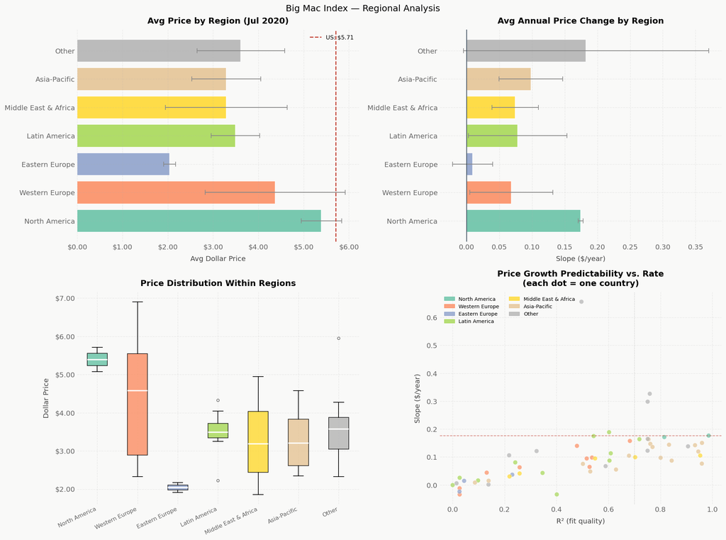

```python
region_order = ['North America','Western Europe','Eastern Europe',
                'Latin America','Middle East & Africa','Asia-Pacific','Other']

# Current average price by region
latest_region = (df[df['date'] == latest_date]
                 .dropna(subset=['dollar_price'])
                 .groupby('region')['dollar_price']
                 .agg(['mean','std','count'])
                 .reindex(region_order).dropna())

# Regional slope summary
region_slope = (country_params.groupby('region')['slope']
                .agg(['mean','std','count'])
                .reindex(region_order).dropna())

fig, axes = plt.subplots(2, 2, figsize=(16, 12), facecolor=PALETTE['bg'])
fig.suptitle('Big Mac Index — Regional Analysis', fontsize=14)

reg_colors = plt.cm.Set2(np.linspace(0, 1, len(latest_region)))

# Avg price by region
axes[0,0].barh(latest_region.index, latest_region['mean'],
               xerr=latest_region['std'], color=reg_colors,
               edgecolor='white', capsize=4, alpha=0.88,
               error_kw={'elinewidth':1.2,'ecolor':'#888'})
if us_price:
    axes[0,0].axvline(us_price, color=PALETTE['primary'], linestyle='--',
                      linewidth=1.5, label=f'US: ${us_price:.2f}')
    axes[0,0].legend(frameon=False, fontsize=9)
axes[0,0].xaxis.set_major_formatter(mticker.FormatStrFormatter('$%.2f'))
style_ax(axes[0,0], f'Avg Price by Region ({latest_date.strftime("%b %Y")})',
         'Avg Dollar Price', '')

# Avg slope by region
axes[0,1].barh(region_slope.index, region_slope['mean'],
               xerr=region_slope['std'], color=reg_colors,
               edgecolor='white', capsize=4, alpha=0.88,
               error_kw={'elinewidth':1.2,'ecolor':'#888'})
axes[0,1].axvline(0, color=PALETTE['secondary'], linewidth=1)
style_ax(axes[0,1], 'Avg Annual Price Change by Region',
         'Slope ($/year)', '')

# Boxplot of current prices by region
region_groups = [df[(df['date']==latest_date) & (df['region']==r)]['dollar_price'].dropna().values
                 for r in region_order if r in df['region'].values]
valid_labels  = [r for r in region_order if r in df['region'].values and
                 len(df[(df['date']==latest_date) & (df['region']==r)]['dollar_price'].dropna()) > 0]
if region_groups:
    bp = axes[1,0].boxplot(region_groups, labels=valid_labels,
                           patch_artist=True, vert=True,
                           medianprops=dict(color='white', linewidth=2),
                           flierprops=dict(marker='o', markersize=4, alpha=0.5))
    for patch, color in zip(bp['boxes'], reg_colors):
        patch.set_facecolor(color); patch.set_alpha(0.8)
    axes[1,0].yaxis.set_major_formatter(mticker.FormatStrFormatter('$%.2f'))
    axes[1,0].set_xticklabels(valid_labels, rotation=25, ha='right', fontsize=9)
    style_ax(axes[1,0], 'Price Distribution Within Regions', '', 'Dollar Price')

# Slope vs R² scatter coloured by region
sc_colors = [reg_colors[region_order.index(r)] if r in region_order else '#ccc'
             for r in country_params['region']]
axes[1,1].scatter(country_params['r2'], country_params['slope'],
                  c=sc_colors, s=50, alpha=0.7, edgecolors='white', linewidth=0.5)
axes[1,1].axhline(us_slope, color=PALETTE['primary'], linestyle='--',
                  linewidth=1, alpha=0.6, label='US slope')
axes[1,1].axvline(0.7, color='#aaa', linestyle=':', linewidth=1, alpha=0.6, label='R²=0.7')
# Legend patches for regions
import matplotlib.patches as mpatches
patches = [mpatches.Patch(color=reg_colors[i], label=region_order[i], alpha=0.8)
           for i in range(len(region_order)) if region_order[i] in country_params['region'].values]
axes[1,1].legend(handles=patches, frameon=False, fontsize=8,
                 loc='upper left', ncol=2)
style_ax(axes[1,1], 'Price Growth Predictability vs. Rate\n(each dot = one country)',
         'R² (fit quality)', 'Slope ($/year)')

plt.tight_layout()
plt.show()
```

## 7. US Price Forecast

Using the linear trend fitted in Section 3.2, this section projects the US Big Mac dollar price forward. A linear extrapolation is intentionally simple — it doesn't account for structural breaks, policy changes, or mean reversion — but it provides a useful baseline and illustrates the compounding effect of even modest annual price growth.

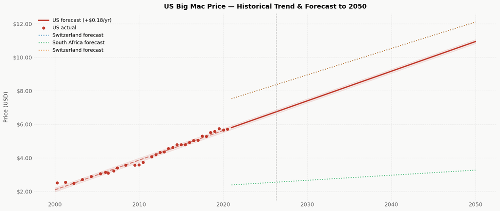

```
US linear forecast:
  2030: $7.40
  2040: $9.17
  2050: $10.94
  (assumes constant +$0.177/year — structural breaks not modelled)
```

```python
us_params = country_params[country_params['name'] == 'United States'].iloc[0]
us_slope_f     = us_params['slope']
us_intercept_f = us_params['intercept']

forecast_years = np.arange(0, 51)   # 2000 → 2050
forecast_dates = pd.to_datetime('2000-01-01') + pd.to_timedelta(forecast_years * 365.25, unit='D')
forecast_price = us_slope_f * forecast_years + us_intercept_f

# Confidence band: ±1 std of residuals
us_obs = df[df['name']=='United States'].dropna(subset=['dollar_price']).copy()
us_obs['years'] = us_obs['date'].dt.year + us_obs['date'].dt.month/12 - 2000
residuals = us_obs['dollar_price'].values - (us_slope_f * us_obs['years'].values + us_intercept_f)
resid_std = residuals.std()

fig, ax = plt.subplots(figsize=(14, 6), facecolor=PALETTE['bg'])

# Forecast band
ax.fill_between(forecast_dates, forecast_price - resid_std, forecast_price + resid_std,
                alpha=0.1, color=PALETTE['primary'])

# Forecast line
split_year = us_obs['years'].max()
hist_mask = forecast_years <= split_year
fore_mask = forecast_years >= split_year

ax.plot(forecast_dates[hist_mask], forecast_price[hist_mask],
        color=PALETTE['primary'], linewidth=2, linestyle='--', alpha=0.6)
ax.plot(forecast_dates[fore_mask], forecast_price[fore_mask],
        color=PALETTE['primary'], linewidth=2.5, linestyle='-',
        label=f'US forecast (+${us_slope_f:.2f}/yr)')

# Actual US data
ax.scatter(us_obs['date'], us_obs['dollar_price'],
           color=PALETTE['primary'], s=25, zorder=5, label='US actual')

# Overlay 2–3 comparison countries
compare_countries = []
if us_price:
    # most expensive and cheapest from latest
    valid_latest = df[df['date']==latest_date].dropna(subset=['dollar_price'])
    compare_countries = ([valid_latest.nlargest(1,'dollar_price').iloc[0]['name']] +
                         [valid_latest.nsmallest(1,'dollar_price').iloc[0]['name']] +
                         (['Switzerland'] if 'Switzerland' in df['name'].values else []))

comp_colors = [PALETTE['accent'], PALETTE['positive'], '#E67E22']
for i, cname in enumerate(compare_countries[:3]):
    cp = country_params[country_params['name']==cname]
    if cp.empty: continue
    cp = cp.iloc[0]
    yrs = np.arange(0, 51)
    dts = pd.to_datetime('2000-01-01') + pd.to_timedelta(yrs*365.25, unit='D')
    ax.plot(dts[fore_mask], cp['slope']*yrs[fore_mask]+cp['intercept'],
            linewidth=1.8, linestyle=':', color=comp_colors[i],
            label=f'{cname} forecast', alpha=0.8)

ax.yaxis.set_major_formatter(mticker.FormatStrFormatter('$%.2f'))
ax.axvline(pd.Timestamp('today'), color='#aaa', linewidth=1, linestyle='--', alpha=0.6)
ax.legend(frameon=False, fontsize=10)
style_ax(ax, 'US Big Mac Price — Historical Trend & Forecast to 2050',
         '', 'Price (USD)')
plt.tight_layout()
plt.show()

price_2030 = us_slope_f * 30 + us_intercept_f
price_2040 = us_slope_f * 40 + us_intercept_f
price_2050 = us_slope_f * 50 + us_intercept_f
print(f'US linear forecast:')
print(f'  2030: ${price_2030:.2f}')
print(f'  2040: ${price_2040:.2f}')
print(f'  2050: ${price_2050:.2f}')
print(f'  (assumes constant +${us_slope_f:.3f}/year — structural breaks not modelled)')
```